# STAT656: Homework 3

Classification with Logistic Regression and Linear Discriminant Analysis

Jack Cunningham

When customers leave a company, this is often referred to as ‘churn’. Churn is a big concern for many service-oriented businesses as there is a cost of acquiring new customers, so keeping existing customers is important to keep costs down. Let’s look into predicting whether a customer will churn for a telecommunications company.

Let’s load in any required packages here (make sure to install them first)

```r
require(dplyr)
require(readr)
require(caret)
require(pROC)
set.seed(1)

trainingData = read_csv('trainingData.csv')
testingData  = read_csv('testingData.csv')
```

Let’s modify the objects somewhat to get a consistent naming convention

```r
Xtrain = select(trainingData, -Churn)
Xtest  = select(testingData, -Churn)
Ytrain = select(trainingData, Churn) %>% unlist()
Ytest  = select(testingData, Churn) %>% unlist()
```

Let’s look at the data structures for the training data:

```r
str(Xtrain)
```

```
## tibble [6,340 × 19] (S3: tbl_df/tbl/data.frame)
##  $ customerID      : chr [1:6340] "5575-GNVDE" "3668-QPYBK" "7795-CFOCW" "9237-HQITU" ...
##  $ gender          : chr [1:6340] "Male" "Male" "Male" "Female" ...
##  $ SeniorCitizen   : num [1:6340] 0 0 0 0 0 0 0 0 0 0 ...
##  $ Partner         : chr [1:6340] "No" "No" "No" "No" ...
##  $ Dependents      : chr [1:6340] "No" "No" "No" "No" ...
##  $ tenure          : num [1:6340] 34 2 45 2 8 22 10 62 13 16 ...
##  $ MultipleLines   : chr [1:6340] "No" "No" "No phone service" "No" ...
##  $ InternetService : chr [1:6340] "DSL" "DSL" "DSL" "Fiber optic" ...
##  $ OnlineSecurity  : chr [1:6340] "Yes" "Yes" "Yes" "No" ...
##  $ OnlineBackup    : chr [1:6340] "No" "Yes" "No" "No" ...
##  $ DeviceProtection: chr [1:6340] "Yes" "No" "Yes" "No" ...
##  $ TechSupport     : chr [1:6340] "No" "No" "Yes" "No" ...
##  $ StreamingTV     : chr [1:6340] "No" "No" "No" "No" ...
##  $ StreamingMovies : chr [1:6340] "No" "No" "No" "No" ...
##  $ Contract        : chr [1:6340] "One year" "Month-to-month" "One year" "Month-to-month" ...
##  $ PaperlessBilling: chr [1:6340] "No" "Yes" "No" "Yes" ...
##  $ PaymentMethod   : chr [1:6340] "Mailed check" "Mailed check" "Bank transfer (automatic)" "Electronic check" ...
##  $ MonthlyCharges  : num [1:6340] 57 53.9 42.3 70.7 99.7 ...
##  $ TotalCharges    : num [1:6340] 1890 108 1841 152 820 ...
```

```r
#Note: we can put the number of unique values with the data structure:
rbind(sapply(Xtrain,function(x){ length(unique(x))}),
      sapply(Xtrain,class))
```

```
##      customerID  gender      SeniorCitizen Partner     Dependents  tenure
## [1,] "6340"      "2"         "2"           "2"         "2"         "73"
## [2,] "character" "character" "numeric"     "character" "character" "numeric"
##      MultipleLines InternetService OnlineSecurity OnlineBackup DeviceProtection
## [1,] "3"           "3"             "3"            "3"          "3"
## [2,] "character"   "character"     "character"    "character"  "character"
##      TechSupport StreamingTV StreamingMovies Contract    PaperlessBilling
## [1,] "3"         "3"         "3"             "3"         "2"
## [2,] "character" "character" "character"     "character" "character"
##      PaymentMethod MonthlyCharges TotalCharges
## [1,] "4"           "1546"         "5918"
## [2,] "character"   "numeric"      "numeric"
```

```r
str(Ytrain)
```

```
##  Named chr [1:6340] "No" "Yes" "No" "Yes" "Yes" "No" "No" "No" "No" "No" ...
##  - attr(*, "names")= chr [1:6340] "Churn1" "Churn2" "Churn3" "Churn4" ...
```

```r
table(Ytrain)
```

```
## Ytrain
##   No  Yes
## 4657 1683
```

# Problem 0 (15 pts)

Remember the items that usually need to be checked:

- data structures
- checking for missing data
- Converting qualitative features to dummy variables
- extreme observations
- transformations
- correlations

For this assignment, in the interest of keeping it short(er), let’s just look at data structures and missing data

## 0.1 Missing data

```r
#### Answer 0.1.1 Check to see if there are any missing values in the training data
anyNA(Xtrain)
```

```
## [1] TRUE
```

```r
#### Answer 0.1.2 Check to see if there are any missing values in the test data
anyNA(Xtest)
```

```
## [1] TRUE
```

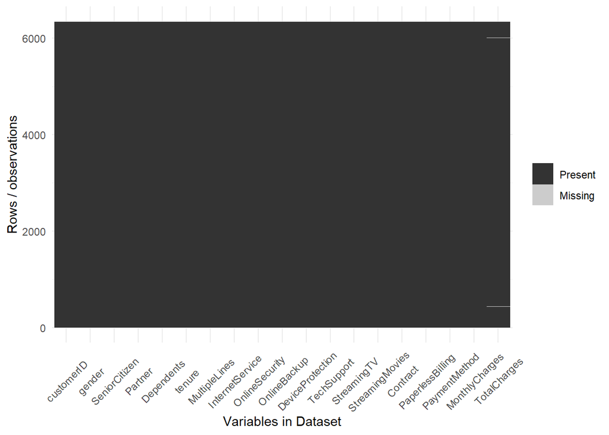

```r
#### Answer 0.1.3 Make a visualization with the function ggplot_missing of the missing data in Xtrain
ggplot_missing = function(x){
    if(!require(reshape2)){warning('you need to install reshape2')}
    require(reshape2)
    require(ggplot2)
    #### This function produces a plot of the missing data pattern
    #### in x.  It is a modified version of a function in the 'neato' package

  x %>%
    is.na %>%
    melt %>%
    ggplot(data = .,
           aes(x = Var2,
               y = Var1)) +
    geom_raster(aes(fill = value)) +
    scale_fill_grey(name = "",
                    labels = c("Present","Missing")) +
    theme_minimal() +
    theme(axis.text.x  = element_text(angle=45, vjust=0.5)) +
    labs(x = "Variables in Dataset",
         y = "Rows / observations")
}
ggplot_missing(Xtrain)
```

It looks like there are just missing values for TotalCharges in both Xtrain and Xtest. Let’s use a linear regression model to impute TotalCharges with MonthlyCharges. Here is how that would work using the training data

```r
trControl = trainControl(method='none')

imputationScheme = train(TotalCharges~MonthlyCharges,
                         data = select(Xtrain,MonthlyCharges, TotalCharges) %>% na.omit,
                         method = 'lm', trControl = trControl)
XtrainImp                 = Xtrain
M                         = is.na(XtrainImp$TotalCharges)
XtrainImp$TotalCharges[M] = predict(imputationScheme,
                                    select(Xtrain, MonthlyCharges, TotalCharges) %>% filter(M))
```

Now, we want to impute the test features using the imputation scheme learned using the training features.

```r
XtestImp = Xtest
#### Answer 0.1.4 Using 'imputationScheme' from 0.1.3, impute the missing value(s) in Xtest
####              Don't retrain a new imputation scheme on the test data, just use the training
####              imputation scheme
M2       = is.na(XtestImp$TotalCharges)
XtestImp$TotalCharges[M2] = predict(imputationScheme, select(Xtest, MonthlyCharges, TotalCharges) |>  filter(M2))
```

## 0.2 Data structures

Now, convert the qualitative features and supervisors to factors.

Hint: you should be on the look out for qualitative features that have too many levels. Encoding them as factors creates a massive number of dummy variables. Also, of course, qualitative features that have the wrong data structure e.g. integer or numeric.

```r
XtrainImpFact = select(XtrainImp, -customerID,
                      -tenure, -MonthlyCharges, -TotalCharges) %>%
  mutate_all(factor)

XtestImpFact = #### Answer 0.2.1 Convert the character data structures in Xtest to factor
  select(XtestImp, -customerID,
         -tenure, -MonthlyCharges, -TotalCharges) |>
  mutate_all(factor)

Ytrain   = factor(Ytrain)

Ytest    = factor(Ytest)#### Answer 0.2.2 Convert the character data structures in Ytest to factor
```

## 0.3 Dummy variables

```r
dummyModel = dummyVars(~ ., data = XtrainImpFact, fullRank = TRUE)

XtrainQualDummy = predict(dummyModel, XtrainImpFact)
XtestQualDummy  = predict(dummyModel, XtestImpFact)
```

Let’s create the full feature matrices for the training and test set

```r
XtrainQuan = select(XtrainImp, tenure, MonthlyCharges, TotalCharges)
XtrainFull = cbind(XtrainQualDummy, XtrainQuan)

XtestQuan  = select(XtestImp, tenure, MonthlyCharges, TotalCharges)
XtestFull  = cbind(XtestQualDummy, XtestQuan)
```

## Some additional processing

Note that there is some redundant information in the qualitative features. Though it isn’t really “correlation” (because we are referring to indicator features), we can still use a corrplot to visualize the problem

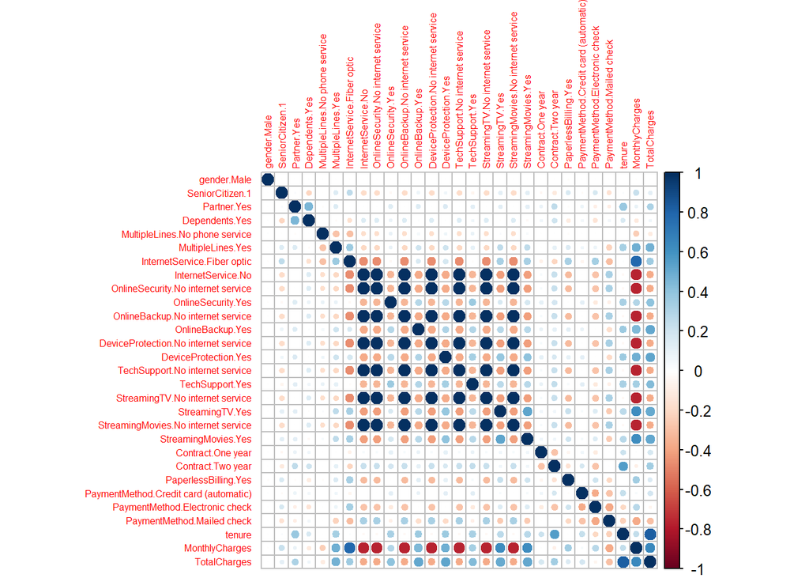

```r
require(corrplot)
corrplot(cor(XtrainFull), tl.cex = 0.5)
```

There are qualitative features like “InternetService” and then other qualitative features like “OnlineBackup” which have a level “no internet service”. These new features overlap exactly and hence we need to remove some of them

```r
XtrainFull = select(XtrainFull,-contains('.No internet'))
XtestFull  = select(XtestFull,-contains('.No internet'))
```

# Problem 1: Logistic Regression (30 pts)

Let’s go through and make a predictive model out of logistic regression

## Train the logistic regression model on the training data

Make sure you are using the trainControl to only train the model by setting method = ‘none’. ‘train’ treats the first level as the event of interest, which is in alphabetical order. So, ‘no’ would be the event. However, we usually want to code results so that the outcome of interest is the event. We can make this adjustment in R via ‘relevel’ on the supervisor

```r
YtrainRelevel = relevel(Ytrain, ref = 'Yes')
YtestRelevel  = relevel(Ytest, ref = 'Yes')

trControl    = trainControl(method = 'none')
outLogistic  = train(x = XtrainFull, y = YtrainRelevel,
                   method = 'glm', trControl = trControl)
```

## Problem 1.2: Get the test predicted probabilities

Get the predicted probabilities for the test data and print out the first few predictions with the ‘head’ function

```r
YhatTestProb = predict(outLogistic, XtestFull, type = 'prob')#### Answer 1.2.1.
head(YhatTestProb)
```

```
##          Yes        No
## 1 0.62959261 0.3704074
## 2 0.60063123 0.3993688
## 3 0.02781752 0.9721825
## 4 0.50092343 0.4990766
## 5 0.16875929 0.8312407
## 6 0.36771916 0.6322808
```

## Problem 1.3: Well-calibrated probabilities

Produce a calibration plot using your predictions of the test Data

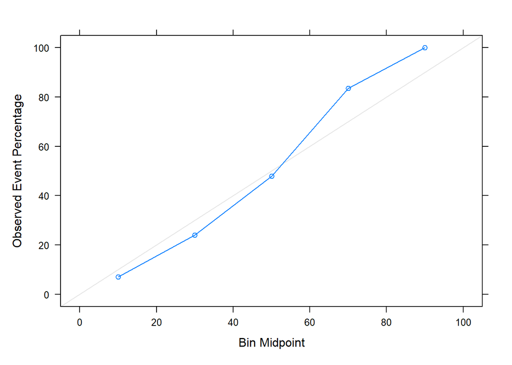

```r
calibProbs = calibration(YtestRelevel ~ YhatTestProb$Yes, cuts = 5)
xyplot(calibProbs)
```

## Problem 1.4: The Confusion matrix

Get the classifications now using the default threshold.

```r
YhatTest = predict(outLogistic, XtestFull, type = 'raw')
```

Look at the help file for the function ‘confusionMatrix’ function. Instead of producing all the output as in the lectures, produce only the confusion matrix, the accuracy rate, kappa, the sensitivity, and the specificity.

```r
confusionMatrixOut = confusionMatrix(reference = YtestRelevel, data = YhatTest)

print(confusionMatrixOut$table)
```

```
##           Reference
## Prediction Yes  No
##        Yes 114  35
##        No   72 482
```

```r
print(confusionMatrixOut$overall[1:2])
```

```
##  Accuracy     Kappa
## 0.8477952 0.5822842
```

```r
#### Answer 1.4.1

print(confusionMatrixOut$byClass[1:2])
```

```
## Sensitivity Specificity
##   0.6129032   0.9323017
```

```r
accuracy = as.numeric(confusionMatrixOut$overall[1])
specificity_t_.5 = as.numeric(confusionMatrixOut$byClass[2])
```

## Problem 1.5: Produce the ROC curve using the test data

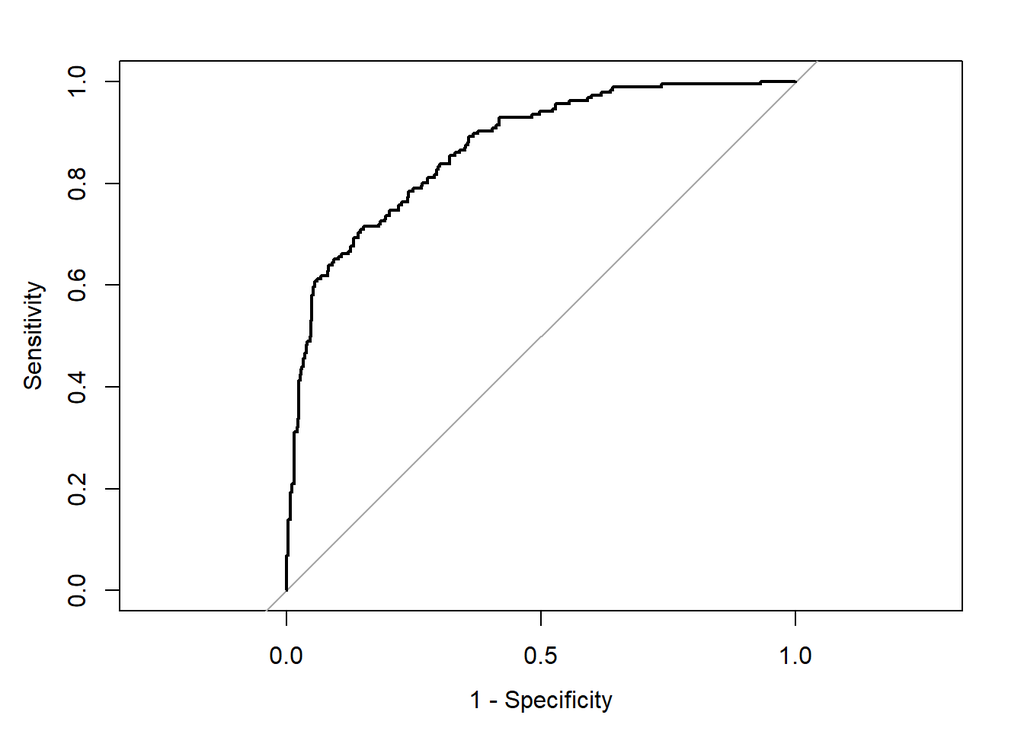

```r
rocCurve = roc(Ytest, YhatTestProb$Yes)
plot(rocCurve, legacy.axes=TRUE)
```

#### Answer 1.5.1.

In no more than 2 sentences, briefly describe this curve. What the objects are being plotted? What value for the threshold would put a classifier at the point (0,0)?

The ROC curve plots the sensitivity and 1 - specificity of our logistic model at varying threshold levels. A threshold of 1 would put a classifier at the point (0,0), at this threshold the classifier would always select a non-event therefore sensitivity would equal zero and specificity would equal 1.

## Problem 1.6: AUC

We can get a one number summary of the ROC from the ‘rocCurve’ object: auc

```r
rocCurve$auc
```

```
## Area under the curve: 0.8689
```

#### Answer 1.6.1

What does the AUC describe? What is a realistic minimum value for the AUC? Maximum value?

The AUC is the area under the ROC curve. It is a measure of classification quality over all threshold decisions. Realistically a minimum value would be .5, a 45 degree line ROC curve corresponding to a model which assigns the observed positive class probability to each observation achieves this minimum. A maximum value would be 1, in which case the classification model makes no mistakes at any threshold.

## Problem 1.7: Achieving a particular sensitivity

What is the specificity for a model that has a sensitivity of at least 0.8? What threshold does it occur at?

```r
thresholds = rocCurve$thresholds

pt8        = which(rocCurve$sensitivities == min(rocCurve$sensitivities[rocCurve$sensitivities > .8]))[1]
#Answer 1.7.1. Fill in the appropriate value and complete this line to get correct index

threshold   = thresholds[pt8]
specificity = rocCurve$specificities[pt8]
sensitivity = rocCurve$sensitivities[pt8]
```

The specificity is 0.7234043.

# Problem 2: Linear Discriminant Analysis (LDA) (20 pts)

Let’s do the same thing for LDA. The code should be nearly identical (hence the power of the ‘caret’ package).

## Train the LDA model on the training data

Make sure you are using the trainControl to only train the model by setting method = ‘none’. ‘train’ treats the first level as the event of interest, which is in alphabetical order. So, ‘no’ would be the event. However, we usually want to code results so that the outcome of interest is the event. We can make this adjustment in R via ‘relevel’ on the supervisor

```r
YtrainRelevel = relevel(Ytrain, ref = 'Yes')
YtestRelevel  = relevel(Ytest, ref = 'Yes')

trControl = trainControl(method = 'none')
outLDA    = train(x = XtrainFull, y = YtrainRelevel,
                  method = 'lda', trControl = trControl)
```

## Get the test predicted probabilities

```r
YhatTestProb = predict(outLDA, XtestFull, type = 'prob')
head(YhatTestProb)
```

```
##          Yes        No
## 1 0.48308863 0.5169114
## 2 0.62943861 0.3705614
## 3 0.05668856 0.9433114
## 4 0.53500672 0.4649933
## 5 0.13409761 0.8659024
## 6 0.29653606 0.7034639
```

## Problem 2.1: Well-calibrated probabilities

Produce a calibration plot using your predictions of the test Data

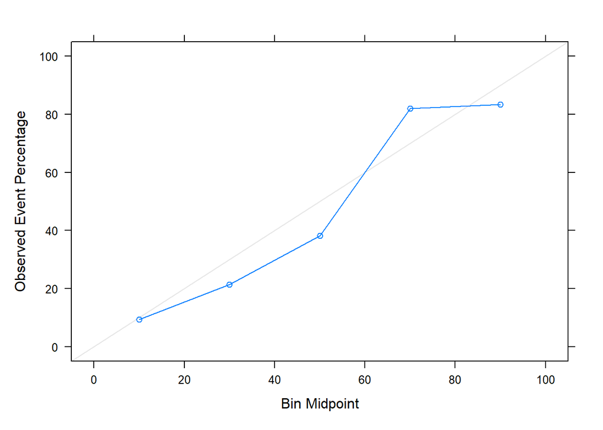

```r
calibProbs = calibration(YtestRelevel ~ YhatTestProb$Yes, cuts = 5)
xyplot(calibProbs)
```

#### Answer 2.1.1. Are these well calibrated probabilities?

They are acceptable but not ideal, there is noticicable deviation in the second, third and fourth bins.

## Problem 2.2: The Confusion matrix

Get the classifications now using the default threshold.

```r
YhatTest = predict(outLDA, XtestFull, type = 'raw')
```

Look at the help file for the function ‘confusionMatrix’ function. Instead of producing all the output as in the lectures, produce only the confusion matrix, the accuracy rate, kappa, the sensitivity, and the specificity.

```r
#### Answer 2.2.1
confusionMatrixOut_lda = confusionMatrix(reference = YtestRelevel, data = YhatTest)

print(confusionMatrixOut_lda$table)
```

```
##           Reference
## Prediction Yes  No
##        Yes 111  40
##        No   75 477
```

```r
print(confusionMatrixOut_lda$overall[1:2])
```

```
##  Accuracy     Kappa
## 0.8364154 0.5526975
```

```r
#### Answer 1.4.1

print(confusionMatrixOut_lda$byClass[1:2])
```

```
## Sensitivity Specificity
##   0.5967742   0.9226306
```

```r
accuracy_lda = as.numeric(confusionMatrixOut_lda$overall[1])
specificity_t_.5_lda = as.numeric(confusionMatrixOut_lda$byClass[2])
```

## Produce the ROC curve using the test data

[figure not shown]

```r
rocCurve_lda = roc(Ytest, YhatTestProb$Yes)
plot(rocCurve, legacy.axes=TRUE)
```

## Problem 2.3: AUC

Get the AUC for LDA

```r
#### Answer 2.3.1
rocCurve_lda$auc
```

```
## Area under the curve: 0.8613
```

## Problem 2.4: Achieving a particular sensitivity

What is the specificity for a model that has a sensitivity as close to .8 as we can make it in this problem? What threshold does it occur at?

```r
#### Answer 2.4.1.
thresholds_lda = rocCurve_lda$thresholds

pt8_lda        = which(rocCurve_lda$sensitivities == min(rocCurve_lda$sensitivities[rocCurve_lda$sensitivities > .8]))[1]
#Answer 1.7.1. Fill in the appropriate value and complete this line to get correct index

threshold_lda   = thresholds_lda[pt8]
specificity_lda = rocCurve_lda$specificities[pt8_lda]
sensitivity_lda = rocCurve_lda$sensitivities[pt8_lda]
```

# Problem 3: Comparison (35 pts)

For this problem, you can either adjust the previous object names so that the correct information is printed here (this would be a great idea) or (as I did in the solutions to make the code look as similar between logistic and lda as possible) you can just write in the relevant information. Report your answers to at least 4 digits after the decimal.

#### Answer 3.1: What are the models’s accuracies? Which model would you prefer based on accuracy?

At a threshold of .5 the accuracy of the two models are the below:

Logistic Regression :0.8477952 LDA :0.8364154

Based on accuracy we would select logistic regression.

#### Answer 3.2: What are the models’s AUCs? Which model would you prefer based on AUC?

The AUC for both models are below:

Logistic Regression : 0.8689191 LDA : 0.8612966 Based on AUC we would select logistic regression.

#### Answer 3.3: What are the models’s specificities? Which model would you prefer based on this?

At a threshold of .5 the specificity of the two models are the below:

Logistic Regression : 0.9323017 LDA : 0.9226306

At this threshold of .5 we would select logistic regression.

At a threshold achieving a sensitivity of .8 the specificity of the two models are the below:

Logistic Regression : 0.7234043 LDA : 0.7059961

We would again choose logistic regression.